# Assessment1.3

Aura Zuluaga

30/05/2021

- Create the heading of the first level and call it Data viz and wrangling

# Data viz and wrangling

- Insert an R chunk and create a variable with this dataset https://raw.githubusercontent.com/rfordatascience/tidytuesday/master/data/2018/2018-09-04/fastfood_calories.csv

The name of the variable should be `fastfood`

```r
fastfood<-read.csv("https://raw.githubusercontent.com/rfordatascience/tidytuesday/master/data/2018/2018-09-04/fastfood_calories.csv")
```

2. Using `skimr` package provide a list of variables which types needs to be changed Use R function to identify the types of variables. What changes do you need to do to correctly record the types of variables? Does all variables have sufficient range (=variability) to be included? Which variable can be removed?

Write 2-3 sentences justifying your view on the above.

```r
library(tidyverse)
library(skimr)
summary(fastfood)
```

```
##        X          restaurant            item              calories
##  Min.   :  1.0   Length:515         Length:515         Min.   :  20.0
##  1st Qu.:129.5   Class :character   Class :character   1st Qu.: 330.0
##  Median :258.0   Mode  :character   Mode  :character   Median : 490.0
##  Mean   :258.0                                         Mean   : 530.9
##  3rd Qu.:386.5                                         3rd Qu.: 690.0
##  Max.   :515.0                                         Max.   :2430.0
##
##     cal_fat         total_fat         sat_fat         trans_fat
##  Min.   :   0.0   Min.   :  0.00   Min.   : 0.000   Min.   :0.000
##  1st Qu.: 120.0   1st Qu.: 14.00   1st Qu.: 4.000   1st Qu.:0.000
##  Median : 210.0   Median : 23.00   Median : 7.000   Median :0.000
##  Mean   : 238.8   Mean   : 26.59   Mean   : 8.153   Mean   :0.465
##  3rd Qu.: 310.0   3rd Qu.: 35.00   3rd Qu.:11.000   3rd Qu.:1.000
##  Max.   :1270.0   Max.   :141.00   Max.   :47.000   Max.   :8.000
##
##   cholesterol         sodium       total_carb         fiber
##  Min.   :  0.00   Min.   :  15   Min.   :  0.00   Min.   : 0.000
##  1st Qu.: 35.00   1st Qu.: 800   1st Qu.: 28.50   1st Qu.: 2.000
##  Median : 60.00   Median :1110   Median : 44.00   Median : 3.000
##  Mean   : 72.46   Mean   :1247   Mean   : 45.66   Mean   : 4.137
##  3rd Qu.: 95.00   3rd Qu.:1550   3rd Qu.: 57.00   3rd Qu.: 5.000
##  Max.   :805.00   Max.   :6080   Max.   :156.00   Max.   :17.000
##                                                   NA's   :12
##      sugar           protein           vit_a            vit_c
##  Min.   : 0.000   Min.   :  1.00   Min.   :  0.00   Min.   :  0.00
##  1st Qu.: 3.000   1st Qu.: 16.00   1st Qu.:  4.00   1st Qu.:  4.00
##  Median : 6.000   Median : 24.50   Median : 10.00   Median : 10.00
##  Mean   : 7.262   Mean   : 27.89   Mean   : 18.86   Mean   : 20.17
##  3rd Qu.: 9.000   3rd Qu.: 36.00   3rd Qu.: 20.00   3rd Qu.: 30.00
##  Max.   :87.000   Max.   :186.00   Max.   :180.00   Max.   :400.00
##                   NA's   :1        NA's   :214      NA's   :210
##     calcium          salad
##  Min.   :  0.00   Length:515
##  1st Qu.:  8.00   Class :character
##  Median : 20.00   Mode  :character
##  Mean   : 24.85
##  3rd Qu.: 30.00
##  Max.   :290.00
##  NA's   :210
```

```r
skim(fastfood)
```

Data summary

| Name | fastfood |
| --- | --- |
| Number of rows | 515 |
| Number of columns | 18 |
| _______________________ |  |
| Column type frequency: |  |
| character | 3 |
| numeric | 15 |
| ________________________ |  |
| Group variables | None |

**Variable type: character**

| skim_variable | n_missing | complete_rate | min | max | empty | n_unique | whitespace |
| --- | --- | --- | --- | --- | --- | --- | --- |
| restaurant | 0 | 1 | 5 | 11 | 0 | 8 | 0 |
| item | 0 | 1 | 5 | 63 | 0 | 505 | 0 |
| salad | 0 | 1 | 5 | 5 | 0 | 1 | 0 |

**Variable type: numeric**

| skim_variable | n_missing | complete_rate | mean | sd | p0 | p25 | p50 | p75 | p100 | hist |
| --- | --- | --- | --- | --- | --- | --- | --- | --- | --- | --- |
| X | 0 | 1.00 | 258.00 | 148.81 | 1 | 129.5 | 258.0 | 386.5 | 515 | ▇▇▇▇▇ |
| calories | 0 | 1.00 | 530.91 | 282.44 | 20 | 330.0 | 490.0 | 690.0 | 2430 | ▇▆▁▁▁ |
| cal_fat | 0 | 1.00 | 238.81 | 166.41 | 0 | 120.0 | 210.0 | 310.0 | 1270 | ▇▃▁▁▁ |
| total_fat | 0 | 1.00 | 26.59 | 18.41 | 0 | 14.0 | 23.0 | 35.0 | 141 | ▇▃▁▁▁ |
| sat_fat | 0 | 1.00 | 8.15 | 6.42 | 0 | 4.0 | 7.0 | 11.0 | 47 | ▇▃▁▁▁ |
| trans_fat | 0 | 1.00 | 0.47 | 0.84 | 0 | 0.0 | 0.0 | 1.0 | 8 | ▇▁▁▁▁ |
| cholesterol | 0 | 1.00 | 72.46 | 63.16 | 0 | 35.0 | 60.0 | 95.0 | 805 | ▇▁▁▁▁ |
| sodium | 0 | 1.00 | 1246.74 | 689.95 | 15 | 800.0 | 1110.0 | 1550.0 | 6080 | ▇▆▁▁▁ |
| total_carb | 0 | 1.00 | 45.66 | 24.88 | 0 | 28.5 | 44.0 | 57.0 | 156 | ▅▇▂▁▁ |
| fiber | 12 | 0.98 | 4.14 | 3.04 | 0 | 2.0 | 3.0 | 5.0 | 17 | ▇▅▂▁▁ |
| sugar | 0 | 1.00 | 7.26 | 6.76 | 0 | 3.0 | 6.0 | 9.0 | 87 | ▇▁▁▁▁ |
| protein | 1 | 1.00 | 27.89 | 17.68 | 1 | 16.0 | 24.5 | 36.0 | 186 | ▇▂▁▁▁ |
| vit_a | 214 | 0.58 | 18.86 | 31.38 | 0 | 4.0 | 10.0 | 20.0 | 180 | ▇▁▁▁▁ |
| vit_c | 210 | 0.59 | 20.17 | 30.59 | 0 | 4.0 | 10.0 | 30.0 | 400 | ▇▁▁▁▁ |
| calcium | 210 | 0.59 | 24.85 | 25.52 | 0 | 8.0 | 20.0 | 30.0 | 290 | ▇▁▁▁▁ |

The data set shows us 2 types of variables: character and numeric. However, some of them require changes in order to approach their visualization properly. For instance, the variable `restaurant` should become a categorical factor as we have a limited of 8 types of restaurant in total. Meanwhile, the variable `item` should remain as character as the number of unique occurrences (505) is almost same as the number of total observations (515). The variable `x` & `salad` does not have sufficient range to be considered, as a result, it can be remove from the viz.Other variables such as `vit_a`, `vit_c` and calcium have a high number of missing occurrences compared to the total of observations so they can be removed from the analysis.

3. Identify variable(s) which should be factors and transform their type into a factor variable.

```r
restaurant<-fastfood$restaurant<-as.factor(fastfood$restaurant)
item<-fastfood$item<-as.factor(fastfood$item)
skim(fastfood)
```

Data summary

| Name | fastfood |
| --- | --- |
| Number of rows | 515 |
| Number of columns | 18 |
| _______________________ |  |
| Column type frequency: |  |
| character | 1 |
| factor | 2 |
| numeric | 15 |
| ________________________ |  |
| Group variables | None |

**Variable type: character**

| skim_variable | n_missing | complete_rate | min | max | empty | n_unique | whitespace |
| --- | --- | --- | --- | --- | --- | --- | --- |
| salad | 0 | 1 | 5 | 5 | 0 | 1 | 0 |

**Variable type: factor**

| skim_variable | n_missing | complete_rate | ordered | n_unique | top_counts |
| --- | --- | --- | --- | --- | --- |
| restaurant | 0 | 1 | FALSE | 8 | Tac: 115, Sub: 96, Bur: 70, Mcd: 57 |
| item | 0 | 1 | FALSE | 505 | Cri: 3, Gri: 3, Che: 2, Chi: 2 |

**Variable type: numeric**

| skim_variable | n_missing | complete_rate | mean | sd | p0 | p25 | p50 | p75 | p100 | hist |
| --- | --- | --- | --- | --- | --- | --- | --- | --- | --- | --- |
| X | 0 | 1.00 | 258.00 | 148.81 | 1 | 129.5 | 258.0 | 386.5 | 515 | ▇▇▇▇▇ |
| calories | 0 | 1.00 | 530.91 | 282.44 | 20 | 330.0 | 490.0 | 690.0 | 2430 | ▇▆▁▁▁ |
| cal_fat | 0 | 1.00 | 238.81 | 166.41 | 0 | 120.0 | 210.0 | 310.0 | 1270 | ▇▃▁▁▁ |
| total_fat | 0 | 1.00 | 26.59 | 18.41 | 0 | 14.0 | 23.0 | 35.0 | 141 | ▇▃▁▁▁ |
| sat_fat | 0 | 1.00 | 8.15 | 6.42 | 0 | 4.0 | 7.0 | 11.0 | 47 | ▇▃▁▁▁ |
| trans_fat | 0 | 1.00 | 0.47 | 0.84 | 0 | 0.0 | 0.0 | 1.0 | 8 | ▇▁▁▁▁ |
| cholesterol | 0 | 1.00 | 72.46 | 63.16 | 0 | 35.0 | 60.0 | 95.0 | 805 | ▇▁▁▁▁ |
| sodium | 0 | 1.00 | 1246.74 | 689.95 | 15 | 800.0 | 1110.0 | 1550.0 | 6080 | ▇▆▁▁▁ |
| total_carb | 0 | 1.00 | 45.66 | 24.88 | 0 | 28.5 | 44.0 | 57.0 | 156 | ▅▇▂▁▁ |
| fiber | 12 | 0.98 | 4.14 | 3.04 | 0 | 2.0 | 3.0 | 5.0 | 17 | ▇▅▂▁▁ |
| sugar | 0 | 1.00 | 7.26 | 6.76 | 0 | 3.0 | 6.0 | 9.0 | 87 | ▇▁▁▁▁ |
| protein | 1 | 1.00 | 27.89 | 17.68 | 1 | 16.0 | 24.5 | 36.0 | 186 | ▇▂▁▁▁ |
| vit_a | 214 | 0.58 | 18.86 | 31.38 | 0 | 4.0 | 10.0 | 20.0 | 180 | ▇▁▁▁▁ |
| vit_c | 210 | 0.59 | 20.17 | 30.59 | 0 | 4.0 | 10.0 | 30.0 | 400 | ▇▁▁▁▁ |
| calcium | 210 | 0.59 | 24.85 | 25.52 | 0 | 8.0 | 20.0 | 30.0 | 290 | ▇▁▁▁▁ |

4. Replace NA in the dataset with 0 across all variables

```r
fastfood$fiber[which(is.na(fastfood$fiber))]<-0
fastfood$protein[which(is.na(fastfood$protein))]<-0
fastfood$vit_a[which(is.na(fastfood$vit_a))]<-0
fastfood$vit_c[which(is.na(fastfood$vit_c))]<-0
fastfood$calcium[which(is.na(fastfood$calcium))]<-0
```

5. Create two new variables:

Read about `cut_number()` function using Help and add a new variable to the dataset `calories_type`. Use the function arguments to add labels `c("low", "med", "high")` and make the dataset ordered.

Do not forget to save the updated dataset.

```r
fastfood<-fastfood%>%
  mutate(calories_type = cut_number(calories,3,labels=c("low","med","high"),ordered_result=TRUE))
fastfood$calories_type
```

```
##   [1] low  high high high high med  low  med  med  high low  high med  high low
##  [16] low  high med  high low  low  med  med  med  high med  med  med  high med
##  [31] high high high high low  med  high high high high low  low  med  high high
##  [46] high high high low  low  med  low  low  med  low  low  med  med  low  low
##  [61] low  low  low  med  med  low  low  low  med  high med  med  low  low  low
##  [76] low  med  med  med  med  med  low  high high high high low  med  low  med
##  [91] med  high high high high high high high high high high high high med  med
## [106] med  med  high med  med  med  low  med  high high high low  med  low  med
## [121] high high high low  med  med  high low  low  med  med  low  low  med  low
## [136] high low  low  med  med  high high high high med  high high med  med  low
## [151] med  high med  high high high med  low  high high high low  low  med  high
## [166] med  high med  high high high med  med  med  high high high med  high low
## [181] low  low  low  low  low  low  low  low  med  med  low  high high high low
## [196] low  high high high low  med  med  low  high med  high low  med  high high
## [211] low  high high high high high high high high high low  low  med  high med
```

[output cut: 21 more lines]

6. Create a dataviz that shows the distribution of `calories_type` in food items for each type of restaurant. Think carefully about the choice of data viz. Use facets, coordinates and theme layers to make your data viz visually appealing and meaningful. Use factors related data viz functions.

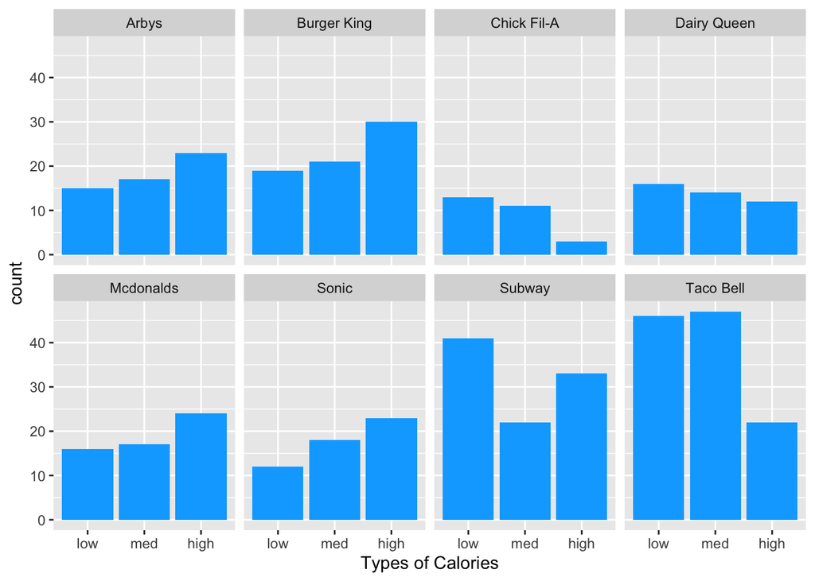

```r
  fastfood%>%ggplot(aes(calories_type))+
  geom_bar(fill="#00abff")+
  facet_wrap(~restaurant,nrow = 2)+
  theme_grey()+
  labs(x="Types of Calories")
```

7. The second variable should show the percentage of `trans_fat` in `total_fat`. Add the variable to the dataset and call it `trans_fat_percent`. Do not forget to save the updated dataset.

```r
fastfood<-fastfood%>%group_by(trans_fat)%>%
  mutate(trans_fat_percent=paste0(round(total_fat/sum(total_fat)*100,2),"%"))
fastfood$trans_fat_percent
```

```
##   [1] "0.11%"  "9.72%"  "14.35%" "2.16%"  "3.13%"  "1.05%"  "0.84%"  "0.37%"
##   [9] "0.79%"  "28.85%" "0.28%"  "7.34%"  "0.31%"  "0.52%"  "0.12%"  "0.08%"
##  [17] "7.78%"  "0.32%"  "2.44%"  "0.23%"  "0.68%"  "0.34%"  "7.13%"  "0.28%"
##  [25] "0.49%"  "0.35%"  "0.34%"  "5.83%"  "7.56%"  "0.31%"  "0.51%"  "7.99%"
##  [33] "0.34%"  "2.51%"  "0.32%"  "0.43%"  "3.06%"  "2.63%"  "3.3%"   "10.31%"
##  [41] "0.17%"  "0.25%"  "0.41%"  "0.81%"  "7.45%"  "0.41%"  "0.61%"  "1.01%"
##  [49] "0.11%"  "0.14%"  "0.43%"  "0.18%"  "0.21%"  "0.43%"  "0.15%"  "0.18%"
##  [57] "0.38%"  "0.25%"  "0.09%"  "0.17%"  "0.09%"  "0.18%"  "0.26%"  "0.35%"
##  [65] "0.35%"  "0.09%"  "0.14%"  "0.18%"  "0.28%"  "0.7%"   "0.29%"  "0.29%"
##  [73] "0.03%"  "0.05%"  "0.06%"  "0.08%"  "0.18%"  "0.2%"   "0.28%"  "0.29%"
##  [81] "0.38%"  "0.21%"  "1.76%"  "0.48%"  "3.15%"  "2.71%"  "0.64%"  "1.67%"
##  [89] "0.86%"  "1.05%"  "2.78%"  "4.32%"  "2.71%"  "2.71%"  "3.51%"  "3.15%"
##  [97] "3.15%"  "3.95%"  "22.6%"  "18.67%" "18.67%" "21.38%" "18.67%" "0.21%"
## [105] "0.21%"  "0.21%"  "0.46%"  "0.6%"   "0.31%"  "0.51%"  "0.37%"  "0.21%"
## [113] "0.37%"  "0.6%"   "4.24%"  "1.53%"  "0.34%"  "1.2%"   "0.26%"  "0.46%"
```

[output cut: 50 more lines]

8. Create a dataviz that shows the distribution of `trans_fat` in food items for each type of restaurant. Think carefully about the choice of data viz. Use facets, coordinates and theme layers to make your data viz visually appealing and meaningful.

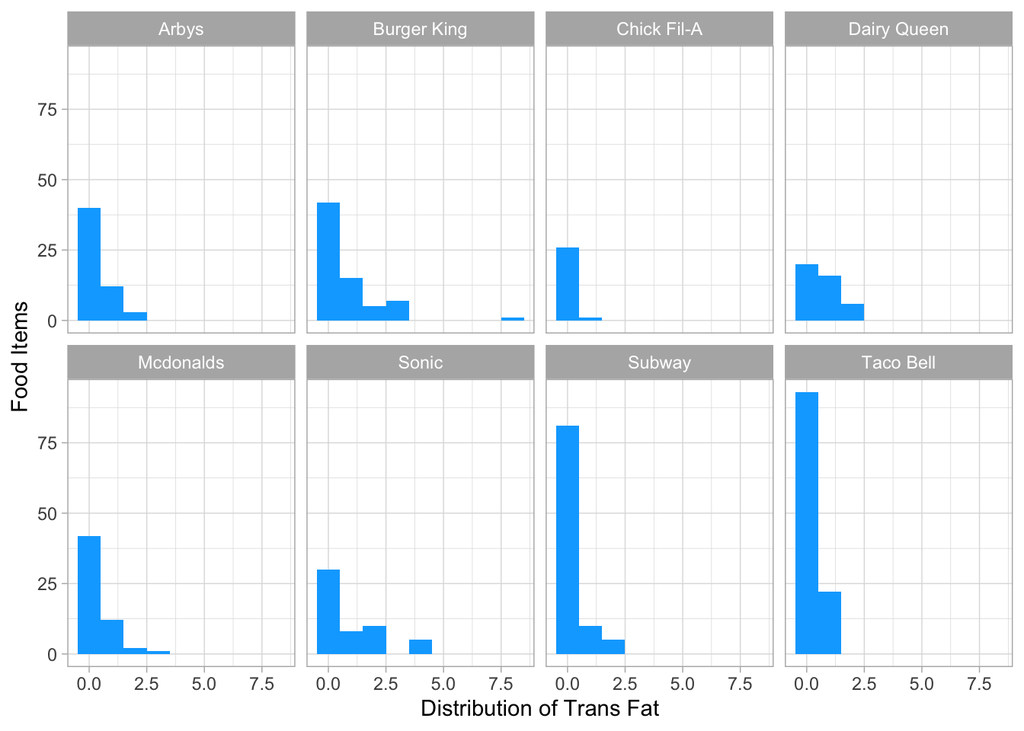

```r
  fastfood%>%ggplot(aes(trans_fat))+
  geom_histogram(binwidth = 1, fill="#00abff")+
  facet_wrap(~restaurant,nrow = 2)+
  labs(x="Distribution of Trans Fat",y="Food Items")+
  theme_light()
```

9. Calculate the average (mean) total_fat for each type of restaurant. No need to save it as a variable.

```r
fastfood%>%group_by(restaurant)%>%
  mutate(average_total_fat=mean(total_fat))%>%
  select(restaurant,average_total_fat)%>%
  distinct(average_total_fat,.keep_all = TRUE)%>%
  arrange(average_total_fat,desc(average_total_fat))%>%
  ungroup()
```

```
## # A tibble: 8 x 2
##   restaurant  average_total_fat
##   <fct>                   <dbl>
## 1 Chick Fil-A              16.1
## 2 Subway                   18.5
## 3 Taco Bell                20.9
## 4 Arbys                    27.0
## 5 Dairy Queen              28.9
## 6 Mcdonalds                31.8
## 7 Burger King              36.8
## 8 Sonic                    37.6
```

10. And create a dataviz that allow to compare different restaurants on this. You can present it on one dataviz (= no facets). Think carefully about the choice of data viz. Use coordinates and theme layers to make your data viz visually appealing and meaningful.

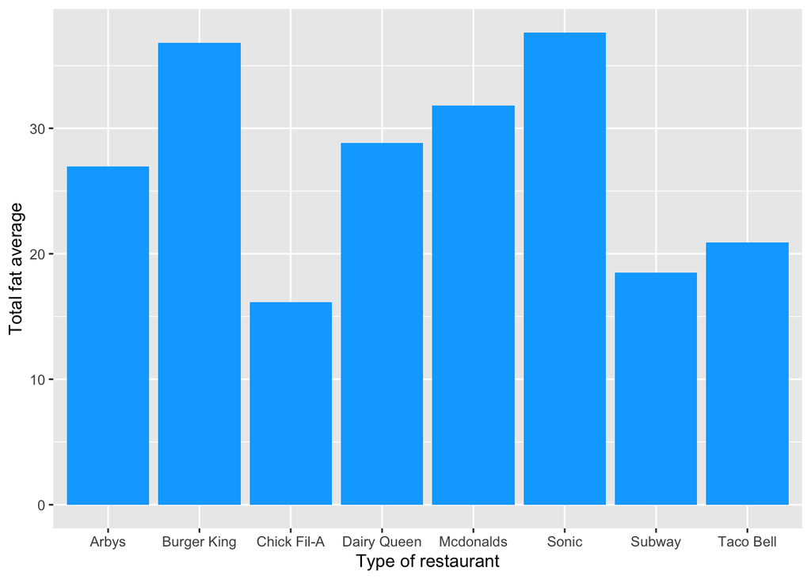

```r
  fastfood%>%group_by(restaurant)%>%
  mutate(average_total_fat=mean(total_fat))%>%
  select(restaurant,average_total_fat)%>%
  distinct(average_total_fat,.keep_all = TRUE)%>%
  arrange(average_total_fat,desc(average_total_fat))%>%
  ungroup()%>%
  ggplot(aes(restaurant,average_total_fat))+
  geom_col(position = "dodge",fill = "#00abff")+
  labs(x="Type of restaurant",y="Total fat average")+
  theme_grey()
```